# p8105 Fall 2018 Homework 1

Adina Zhang

September 13, 2018

# Problem 1

```r
set.seed(1)

# Create a new dataframe comprised of multiple variable types
var_df <- tibble(
  vec_norm = runif(10, min = 0, max = 5),
  vec_logical = ifelse(vec_norm > 2, TRUE, FALSE),
  vec_char = c("apple", "orange", "lemon", "jackfruit", "papaya", "mango", "raspberry", "tomato", "cucumber", "lime"),
  vec_factor = factor(c("summer", "winter", "summer", "spring", "summer", "winter", "fall", "fall", "winter", "fall"))
)

var_df
```

```
## # A tibble: 10 x 4
##    vec_norm vec_logical vec_char  vec_factor
##       <dbl> <lgl>       <chr>     <fct>
##  1    1.33  FALSE       apple     summer
##  2    1.86  FALSE       orange    winter
##  3    2.86  TRUE        lemon     summer
##  4    4.54  TRUE        jackfruit spring
##  5    1.01  FALSE       papaya    summer
##  6    4.49  TRUE        mango     winter
##  7    4.72  TRUE        raspberry fall
##  8    3.30  TRUE        tomato    fall
##  9    3.15  TRUE        cucumber  winter
## 10    0.309 FALSE       lime      fall
```

```r
# Calculate the mean of each variable in dataframe var_df
sapply(var_df,mean)
```

```
##    vec_norm vec_logical    vec_char  vec_factor
##    2.757569    0.600000          NA          NA
```

Only `vec_norm` and `vec_logical` were successful in producing a mean. The normal vector is numeric type which is read by the mean function. The logical vector containing “TRUE” and “FALSE” are translated to numeric types “1” and “0” which are also read by the mean function. Character and factor types are not read by the mean function which is why NA was the output for `vec_char` and `vec_factor`.

## Converting variable types

```r
# Convert var_df variables to numeric type
sapply(var_df,as.numeric)
```

[output not shown]

When `vec_logical` is converted to numeric, the output is “0” or “1”. Similarly, when `vec_factor` is converted to numeric, the different levels/categories of the variable are converted to numbers. Since I have four factors (spring, summer, fall, and winter) my `vec_factor` converted to 1-4. `vec_char` did not successfully convert to numeric type, the output is “NA”.

```r
# Convert a character vector to factor type and then to numeric type
as.numeric(as.factor(var_df$vec_char))
```

[output not shown]

```r
# Convert a factor vector to character type and then to numeric type
as.numeric(as.character(var_df$vec_factor))
```

[output not shown]

When a character type is converted first into a factor and then numeric type, it successfully outputs numbers instead of “NA”. If we convert a factor to character and then to numeric type, we once again output “NA”. In conclusion, a character type variable will not directly be converted into a numeric type. It must first be converted to factor before numeric.

# Problem 2

```r
set.seed(1)

# Create a new dataframe containing multiple variable types
plot_df <- tibble(
  x = rnorm(1000),
  y = rnorm(1000),
  vec_logical = ifelse(x + y > 0, TRUE, FALSE),
  vec_numeric = as.numeric(vec_logical),
  vec_factor = as.factor(vec_logical)
)

plot_df
```

```
## # A tibble: 1,000 x 5
##         x       y vec_logical vec_numeric vec_factor
##     <dbl>   <dbl> <lgl>             <dbl> <fct>
##  1 -0.626  1.13   TRUE                  1 TRUE
##  2  0.184  1.11   TRUE                  1 TRUE
##  3 -0.836 -0.871  FALSE                 0 FALSE
##  4  1.60   0.211  TRUE                  1 TRUE
##  5  0.330  0.0694 TRUE                  1 TRUE
##  6 -0.820 -1.66   FALSE                 0 FALSE
##  7  0.487  0.811  TRUE                  1 TRUE
##  8  0.738 -1.91   FALSE                 0 FALSE
##  9  0.576 -1.25   FALSE                 0 FALSE
## 10 -0.305  0.998  TRUE                  1 TRUE
## # ... with 990 more rows
```

The dataframe `plot_df` has 1000 observations and 5 variables: x, y, vec_logical, vec_numeric, and vec_factor. The mean of variable x is -0.0116481 and the median of varialbe x is -0.0353242. The proportion of `TRUE` there are in `vec_logical` is 0.49.

## Scatterplots

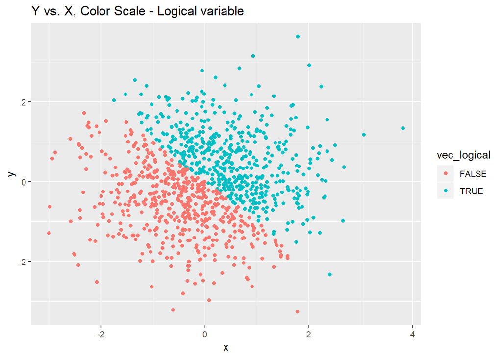

```r
# Create scatterplot for y vs. x, points colored by logical variable
ggplot(plot_df, aes(x = x, y = y, color = vec_logical)) + geom_point() + ggtitle("Y vs. X, Color Scale - Logical variable")
```

```r
ggsave("HW1_scatterplot.png")
```

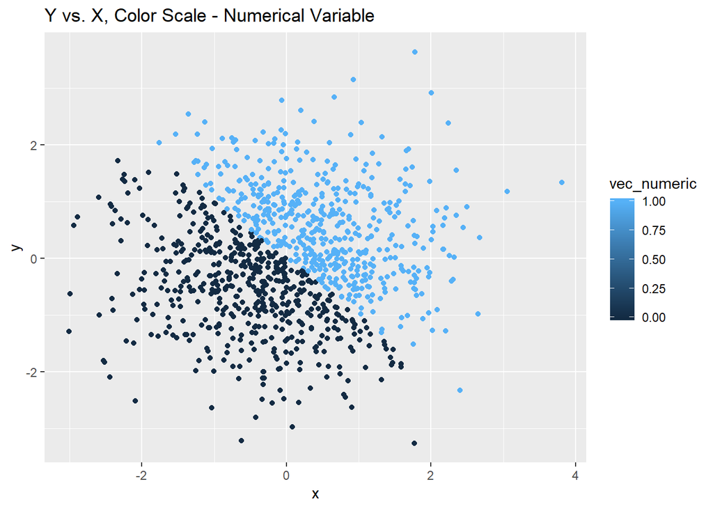

```r
# Create scatterplot for y vs. x, points colored by numerical variable
ggplot(plot_df, aes(x = x, y = y, color = vec_numeric)) + geom_point() + ggtitle("Y vs. X, Color Scale - Numerical Variable")
```

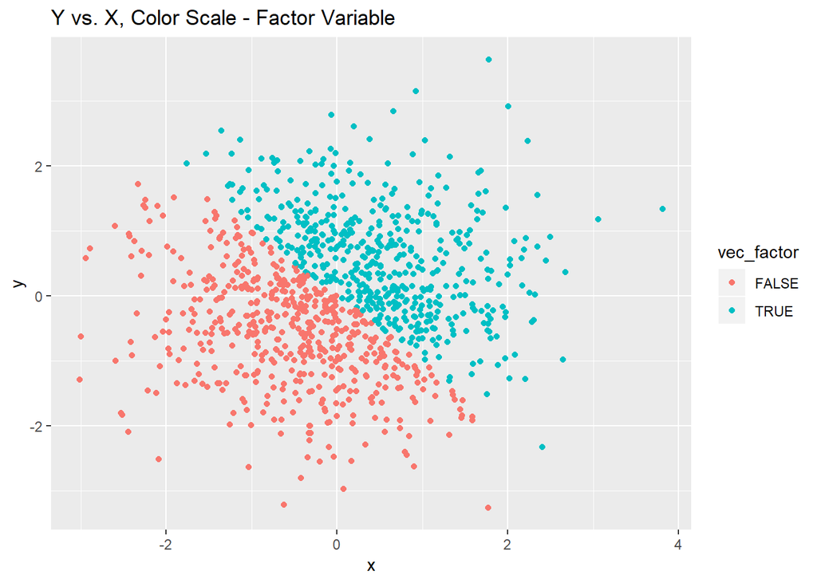

```r
# Create scatterplot for y vs. x, points colored by factor variable
ggplot(plot_df, aes(x = x, y = y, color = vec_factor)) + geom_point() + ggtitle("Y vs. X, Color Scale - Factor Variable")
```